# R Notebook

#STEP 1: Choose the variables

We aim to investigate whether COVID-19 severity influences COL11A2 expression, whether patient sex affects COL11A2 expression and whether there is an interaction between sex and disease severity in determining COL11A2 levels. The hypotheses are formulated as follows: - Null hypothesis (H0): The expression of COL11A2 will not be influenced by the sex of the patient and the Covid-19 severity - Alternative hypothesis (H1): The expression of COL11A2 will be influenced by the sex of the patient and the Covid-19 severity

Why COL11A2? This protein was selected because it was mentioned in the article. This collagen protein is part of the down-regulated pathways “Integrin cell surface interactions” and “Collagen biosynthesis and modifying enzymes,” both of which include multiple collagen proteins.

```r
install.packages("ggpubr")

library(ggplot2)
library(dplyr)
library(ggpubr)
library(tidyverse)
```

#STEP 2: Make the dataset Because WHO_temp_severity and the protein of interest are present in other dataframes, we have to make a new dataframe. In this way we can easily check our hypothesis.

```r
# Import whole dataset
combined_dataset <- read.csv("combined_dataset.csv")

# Split dataset in subsets
combined_dataset_protein <-combined_dataset[,1:7241]
proteins_log <- log(combined_dataset_protein[,2:7241])
proteins_scaled <- as.data.frame(scale(proteins_log))

feature_df <-combined_dataset[,7242:7258]

data_multivariate <- data.frame( COL11A2 = proteins_scaled$COL11A2, severity = feature_df$WHO_temp_severity, sex = feature_df$sex)
data_multivariate$severity <- factor(data_multivariate$severity, levels = c("NEGATIVE", "mild", "moderate", "severe", "critical"))
```

#STEP 3: Check for outliers

```r
protein <- combined_dataset$COL11A2

Q1 <- quantile(protein, 0.25, na.rm = TRUE)
Q3 <- quantile(protein, 0.75, na.rm = TRUE)
IQR_value <- IQR(protein, na.rm = TRUE)

lower_bound <- Q1 - 1.5 * IQR_value
upper_bound <- Q3 + 1.5 * IQR_value

outliers <- protein[protein < lower_bound | protein > upper_bound]

outliers
```

```
 [1] 14059.1 11043.5  8828.0  8977.9 10079.4  9938.0 10522.9  8040.3  9685.6
[10] 11337.0  8650.3 11166.6 11076.8 12590.7  9094.0 11050.3  8299.4 10443.6
[19] 14506.3 13175.1  9877.9 13243.2 13882.3
```

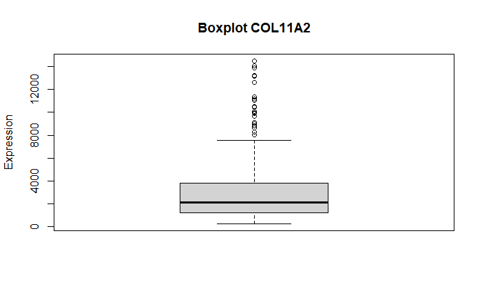

```r
boxplot(protein, main="Boxplot COL11A2", ylab="Expression")
```

INTERPRETATION: There are outliers present but we will chose to not remove these as we cannot explain why these are present.

#STEP 4: Data exploration

We first visualized the distribution of log-transformed and standardized COL11A2 across the different Covid-19 severity levels. This showed that COL11A2 will be downregulated as Covid-19 becomes more severe

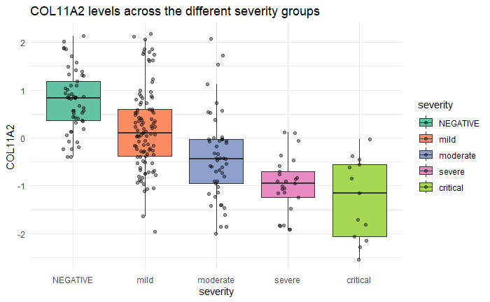

```r
ggplot(data_multivariate, aes(x = severity, y = COL11A2, fill= severity)) +
  geom_boxplot(outliers = FALSE) +
  geom_jitter (width =0.15, alpha =0.4, color = "black") +
  scale_fill_brewer(palette = "Set2") +
  theme_minimal()+
  labs(title = "COL11A2 levels across the different severity groups")
```

We also looked at the distribution of COL11A2 in male and female patients. We noticed that there was not big difference between the two groups.

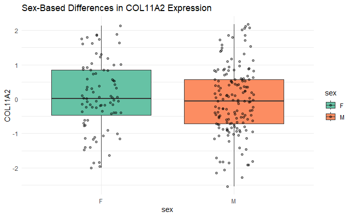

```r
ggplot(data_multivariate, aes(x = sex, y = COL11A2, fill= sex)) +
  geom_boxplot(outliers = FALSE) +
  geom_jitter (width =0.15, alpha =0.4, color = "black") +
  scale_fill_brewer(palette = "Set2") +
  theme_minimal()+
  labs (title = "Sex-Based Differences in COL11A2 Expression ")
```

#STEP 5: Check assumptions

**Normalization of protein COL11A2**

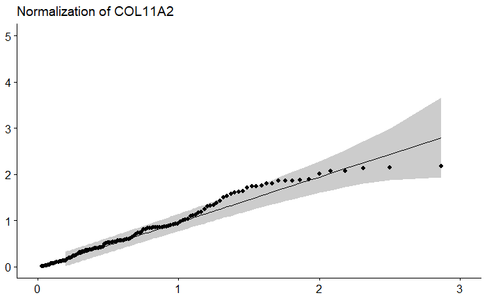

```r
ggqqplot(proteins_scaled$COL11A2) +
  ylim(0,5)+
  xlim(0,3)+
  labs(title = "Normalization of COL11A2", x= NULL, y=NULL)
```

**Normalization of severity**

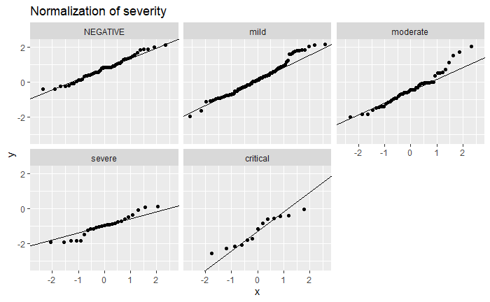

```r
data_multivariate %>%
  ggplot(aes(sample = COL11A2)) +
  geom_qq() +
  geom_qq_line() +
  facet_wrap(~severity) +
  labs( title= "Normalization of severity" )
```

**Normalization of sex**

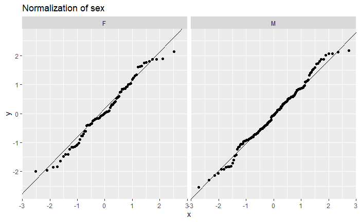

```r
data_multivariate %>%
  ggplot(aes(sample = COL11A2)) +
  geom_qq() +
  geom_qq_line() +
  facet_wrap(~sex)+
  labs( title= "Normalization of sex" )
```

Interpretation of the normality: The normal distribution is not perfect, largely due to the presence of outliers.

**Check assumptions based on a simple linear regression model**

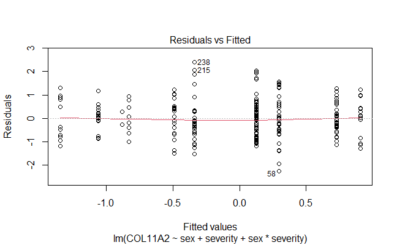

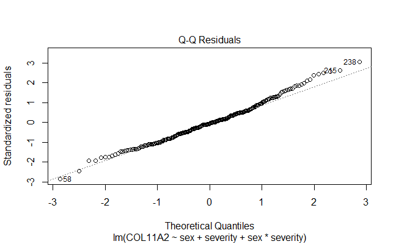

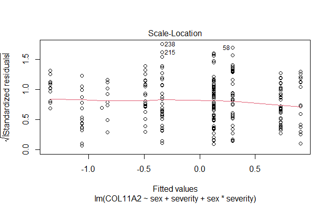

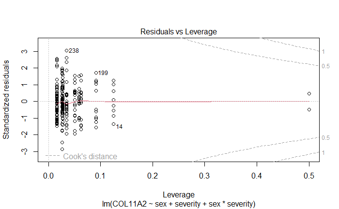

```r
lm_COL11A2 <- lm(COL11A2 ~ sex + severity + sex*severity, data= data_multivariate)
plot(lm_COL11A2)
```

INTERPRETATION: - linearity: Good because: 1) There is almost no curvature in the red line which means that there is no systematic pattern. 2) The residuals are randomly scattered around zero (no under or over prediction) 3) If the variance of the residuals increased or decreased with fitted values, we would see a funnel or cone. This is not present 4) there are a few outliers but this will not form a problem - Normality: looks good - Homocedacity: The red line is mostly flat with only slight deviations. The spread of residuals doesn’t show a strong funnel or curvature. This suggests that our model likely meets the equal variance assumption. - Outliers: There are a few present

# STEP 6: The two-sample Anova test

Because our data is approximately normally distributed, we selected a two-way ANOVA to test our multivariate hypothesis.

```r
anova_model <- aov( COL11A2 ~ severity + sex + severity * sex , data = data_multivariate)
summary(anova_model)
```

```
              Df Sum Sq Mean Sq F value Pr(>F)
severity       4  89.52  22.380  34.804 <2e-16 ***
sex            1   0.70   0.705   1.096  0.296
severity:sex   4   1.23   0.309   0.480  0.751
Residuals    231 148.54   0.643
---
Signif. codes:  0 ‘***’ 0.001 ‘**’ 0.01 ‘*’ 0.05 ‘.’ 0.1 ‘ ’ 1
```

INTERPRETATION: - The difference between severity groups is significant (p < 0,05) = The covid 19 severity has a significant effect on the expression of COL11A2

- The difference between men and female is not significant (p > 0,05) = Sex does not have a significant effect on the expression of COL11A2
- The interaction between sex and severity groups is not significant (p > 0,05) = The covid 19 severity is +/- the same in male and female

The anova model was repeated for the interaction between COL11A2 and severity to use for the post hoc analysis

```r
sign_anova <- aov( COL11A2 ~ severity , data = data_multivariate)
summary(sign_anova)
```

```
             Df Sum Sq Mean Sq F value Pr(>F)
severity      4  89.52  22.380    35.1 <2e-16 ***
Residuals   236 150.48   0.638
---
Signif. codes:  0 ‘***’ 0.001 ‘**’ 0.01 ‘*’ 0.05 ‘.’ 0.1 ‘ ’ 1
```

#STEP 7: Post hoc analyse

We know that Covid-19 severity has a significant effect on the expression of COL11A2. It is important that we do a Post-hoc test to find out for which groups the expression is significantily different.

```r
install.packages("multcomp")
library(multcomp)

mcp <- glht(sign_anova,linfct = mcp (severity = 'Tukey' ))
summary(mcp)
```

```
     Simultaneous Tests for General Linear Hypotheses

Multiple Comparisons of Means: Tukey Contrasts


Fit: aov(formula = COL11A2 ~ severity, data = data_multivariate)

Linear Hypotheses:
                         Estimate Std. Error t value Pr(>|t|)
mild - NEGATIVE == 0      -0.5923     0.1354  -4.373  < 0.001 ***
moderate - NEGATIVE == 0  -1.1851     0.1583  -7.489  < 0.001 ***
severe - NEGATIVE == 0    -1.7688     0.1937  -9.130  < 0.001 ***
critical - NEGATIVE == 0  -2.0581     0.2471  -8.328  < 0.001 ***
moderate - mild == 0      -0.5928     0.1390  -4.264  < 0.001 ***
severe - mild == 0        -1.1764     0.1784  -6.595  < 0.001 ***
critical - mild == 0      -1.4658     0.2353  -6.230  < 0.001 ***
severe - moderate == 0    -0.5836     0.1963  -2.974  0.02464 *
critical - moderate == 0  -0.8730     0.2491  -3.504  0.00453 **
critical - severe == 0    -0.2893     0.2730  -1.060  0.81795
---
Signif. codes:  0 ‘***’ 0.001 ‘**’ 0.01 ‘*’ 0.05 ‘.’ 0.1 ‘ ’ 1
(Adjusted p values reported -- single-step method)
```

```r
confint(mcp)
```

```
     Simultaneous Confidence Intervals

Multiple Comparisons of Means: Tukey Contrasts


Fit: aov(formula = COL11A2 ~ severity, data = data_multivariate)

Quantile = 2.7223
95% family-wise confidence level


Linear Hypotheses:
                         Estimate lwr      upr
mild - NEGATIVE == 0     -0.59234 -0.96106 -0.22363
moderate - NEGATIVE == 0 -1.18514 -1.61595 -0.75432
severe - NEGATIVE == 0   -1.76879 -2.29622 -1.24135
critical - NEGATIVE == 0 -2.05810 -2.73091 -1.38530
moderate - mild == 0     -0.59279 -0.97125 -0.21434
severe - mild == 0       -1.17644 -1.66205 -0.69084
critical - mild == 0     -1.46576 -2.10630 -0.82522
severe - moderate == 0   -0.58365 -1.11794 -0.04936
critical - moderate == 0 -0.87296 -1.55116 -0.19477
critical - severe == 0   -0.28932 -1.03264  0.45401
```

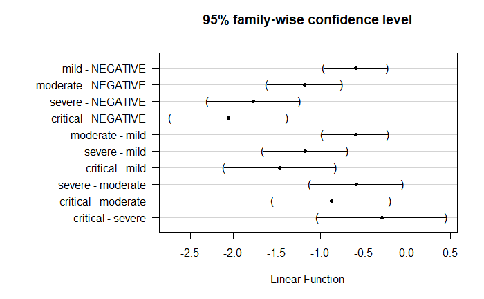

```r
par(mar = c(5, 12, 4, 2)) # bottom, left, top, right
plot(mcp)
```

INTERPRETATION: Tukey post-hoc comparisons showed that all severity groups (mild, moderate, severe and critical) exhibited significantly lower COL11A2 expression compared with the negative group (all p < 0 .001). Furthermore, a clear decrease in expression was observed from mild to moderate, severe and critical disease (all p < 0 .05). The difference between moderate and severe as well as the difference between moderate and critical is also significant. This can however be due to a limited sample size of the severe and critical group.

**Visualisation**

This boxplots supports the results obtained via the two-way ANOVA test

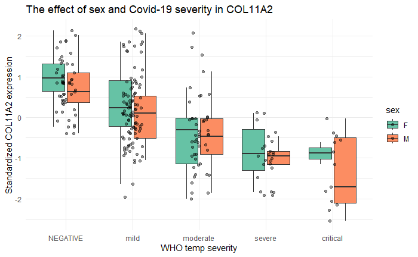

```r
library(ggplot2)


ggplot(data_multivariate, aes(x = severity, y = COL11A2, fill = sex)) +
  geom_boxplot(outliers = FALSE) +
  geom_jitter (width =0.15, alpha =0.4, color = "black") +
  scale_fill_brewer(palette = "Set2") +
  theme_minimal() +
  labs(title = "The effect of sex and Covid-19 severity in COL11A2", x = "WHO temp severity", y = "Standardized COL11A2 expression")
```